# Principal Component Analysis (PCA)

Oleh : Fayadh Abiyyi

## **A. Introduction**

> Komponen utama *( principal component )* adalah kombinasi linier dari variabel asli dan tidak berkorelasi satu dengan lainnya.

> Komponen utama yang terbentuk akan diurutkan sehingga beberapa komponen pertama akan menjelaskan sebagian besar variasi di dalam variabel asli dan komponen utama pertama akan memiliki proporsi varian terbesar.

> Analisis komponen utama berkaitan dengan penjelasan struktur varians-kovarian dari satu set variabel melalui beberapa kombinasi linier dari variabel-variabel tersebut.

#### **Tujuan umumnya adalah:**

> A.) Reduksi dimensi data

> B.) Kemudahan interpretasi.

> Meskipun sebanyak p komponen diperlukan untuk mereproduksi variabilitas sistem total, sering kali sebagian besar variabilitas ini dapat dijelaskan oleh sejumlah kecil k komponen utama. Setiap komponen utama dibentuk dengan mengambil nilai elemen vektor eigen sebagai bobot dari kombinasi linier Yi, dimana Yi adalah variable komposit baru yang disebut sebagai komponen utama.

#### **Interpretasi komponen utama terkait dua hal yaitu:**

> 1. *Importance of component* yaitu seberapa penting setiap komponen utama yang terbentuk dengan melihat proporsi varians yang disumbangkan setiap komponen terhadap total varians sampel.

> 2. I*mportance of each original variable within each component* yaitu seberapa penting suatu variable original dalam pembentukan suatu komponen utama.

## **B. Dataset**

> Data ini dikumpulkan untuk menyelidiki faktor penentu polusi. Variabel berikut diperoleh dari 41 kota di Amerika Serikat:
> - SO2 : Kandungan SO2 di udara dalam mikrogram per meter kubik;
> - temp : suhu tahunan rata-rata dalam derajat Fahrenheit;
> - manu : jumlah perusahaan manufaktur yang mempekerjakan 20 atau lebih pekerja;
> - popul : ukuran populasi (sensus 1970) dalam ribuan;
> - wind : kecepatan angin tahunan rata-rata dalam mil per jam;
> - precip : curah hujan tahunan rata-rata dalam inci;
> - predays: jumlah hari rata-rata dengan curah hujan per tahun.

## **C. Problem**

> Tujuan utama peneliti saat mengumpulkan data polusi udara adalah untuk menentukan variabel iklim dan ekologi manusia mana yang merupakan prediktor terbaik tingkat polusi udara di suatu kota yang diukur dengan kandungan sulfur dioksida di udara. Pertanyaan ini biasanya akan dijawab dengan regresi linier berganda, tetapi ada masalah potensial dengan penerapan teknik ini pada data polusi udara, dan itu adalah **korelasi yang sangat tinggi antara variabel manu dan popul** (multikolinearitas).

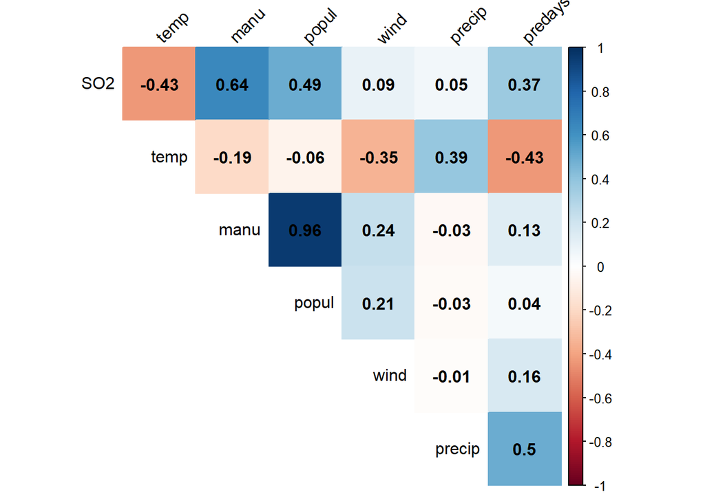

## **D. Analysis**

> Salah satu solusi untuk mengatasi permasalahan tersebut kita akan menggunakan analisis komponen utama sebagai berikut:

### **1.) Impor dan baca data**

```r
library(tidyverse) # load library untuk manipulasi dan visualisasi data
library(rio) # load library untuk import data dari github
praktikum8 <- import("https://raw.githubusercontent.com/fayadh-abi/stis/main/dataset/air_pollution.csv")
head(praktikum8)
```

```
##            V1 SO2 temp manu popul wind precip predays
## 1      Albany  46 47.6   44   116  8.8  33.36     135
## 2 Albuquerque  11 56.8   46   244  8.9   7.77      58
## 3     Atlanta  24 61.5  368   497  9.1  48.34     115
## 4   Baltimore  47 55.0  625   905  9.6  41.31     111
## 5     Bu\valo  11 47.1  391   463 12.4  36.11     166
## 6  Charleston  31 55.2   35    71  6.5  40.75     148
```

```r
praktikum8.fix <- praktikum8 %>% select(-V1) %>% as_tibble() # menghilangkan variabel V1
head(praktikum8.fix)
```

```
## # A tibble: 6 x 7
##     SO2  temp  manu popul  wind precip predays
##   <int> <dbl> <int> <int> <dbl>  <dbl>   <int>
## 1    46  47.6    44   116   8.8  33.4      135
## 2    11  56.8    46   244   8.9   7.77      58
## 3    24  61.5   368   497   9.1  48.3      115
## 4    47  55     625   905   9.6  41.3      111
## 5    11  47.1   391   463  12.4  36.1      166
## 6    31  55.2    35    71   6.5  40.8      148
```

### **2.) Manipulasi data dan melakukan PCA secara manual**

```r
# Membuat variabel baru negtemp (nilai negative dari temperatur)
praktikum8.fix <- praktikum8.fix %>% mutate(negtemp=-1*temp)
praktikum8.fix <- select(praktikum8.fix,-c(SO2,temp)) # Menghilangkan variabel temp dan SO2
praktikum8.standar <- scale(praktikum8.fix) # standarisasi data sehingga memiliki mean = 0 dan sd = 1
cov(praktikum8.standar) # matriks kovarian untuk data yang telah distandarisasi
```

```
##                manu       popul        wind      precip    predays
## manu     1.00000000  0.95526935  0.23794683 -0.03241688 0.13182930
## popul    0.95526935  1.00000000  0.21264375 -0.02611873 0.04208319
## wind     0.23794683  0.21264375  1.00000000 -0.01299438 0.16410559
## precip  -0.03241688 -0.02611873 -0.01299438  1.00000000 0.49609671
## predays  0.13182930  0.04208319  0.16410559  0.49609671 1.00000000
## negtemp  0.19004216  0.06267813  0.34973963 -0.38625342 0.43024212
##             negtemp
## manu     0.19004216
## popul    0.06267813
## wind     0.34973963
## precip  -0.38625342
## predays  0.43024212
## negtemp  1.00000000
```

```r
cor(praktikum8.fix) # Matriks korlasi variabel awal akan sama dengan matriks kovarian variabel yang distandarisasi
```

```
##                manu       popul        wind      precip    predays
## manu     1.00000000  0.95526935  0.23794683 -0.03241688 0.13182930
## popul    0.95526935  1.00000000  0.21264375 -0.02611873 0.04208319
## wind     0.23794683  0.21264375  1.00000000 -0.01299438 0.16410559
## precip  -0.03241688 -0.02611873 -0.01299438  1.00000000 0.49609671
## predays  0.13182930  0.04208319  0.16410559  0.49609671 1.00000000
## negtemp  0.19004216  0.06267813  0.34973963 -0.38625342 0.43024212
##             negtemp
## manu     0.19004216
## popul    0.06267813
## wind     0.34973963
## precip  -0.38625342
## predays  0.43024212
## negtemp  1.00000000
```

```r
p <- ncol(praktikum8.fix)
p # Jumlah variabel bebas
```

```
## [1] 6
```

```r
eig.val <- eigen(cov(praktikum8.standar),symmetric = T)$value # bisa juga didapatkan dari eigen(matriks korelasi)
eig.val # nilai eigen
```

```
## [1] 2.19616264 1.49994343 1.39464912 0.76022689 0.11457065 0.03444727
```

```r
eig.vec <- eigen(cov(praktikum8.standar),symmetric = T)$vectors
eig.vec # vektor eigen
```

```
##             [,1]       [,2]        [,3]        [,4]        [,5]        [,6]
## [1,] -0.61154243  0.1680577 -0.27288633 -0.13684076  0.10204211  0.70297051
## [2,] -0.57782195  0.2224533 -0.35037413 -0.07248126 -0.07806551 -0.69464131
## [3,] -0.35383877 -0.1307915  0.29725334  0.86942583 -0.11326688  0.02452501
## [4,]  0.04080701 -0.6228578 -0.50456294  0.17114826  0.56818342 -0.06062222
## [5,] -0.23791593 -0.7077653  0.09308852 -0.31130693 -0.58000387  0.02196062
## [6,] -0.32964613 -0.1275974  0.67168611 -0.30645728  0.55805638 -0.13618780
```

```r
stdev <- sqrt(eig.val) # standar deviasi didapat dari akar nilai eigen
tot.var <- sum(eig.val) # varian total didapat dari jumlah nilai eigen
prop.var <- eig.val/tot.var # proporsi varian
cum.var <- c(rep(NA,p)) # varian komulatif
x.temp <- 0
for (i in 1:p){
 x.temp <- x.temp+prop.var[i]
 cum.var[i] <- x.temp
}

variabel <- colnames(praktikum8.fix)
vect.name <- c()
for ( i in 1:p){ # Membuat nama komponen
  vect.name[i] <- paste0("Comp.",i)
}
eig.vec <- as.data.frame(eig.vec)
names(eig.vec) <- vect.name
# pembuatan tabel std,prop.varians,dan prop.varians komulatif.
tabel.ic <- rbind(stdev,prop.var,cum.var)
tabel.ic <- as.data.frame(tabel.ic)
row.names(tabel.ic) <- c("Standard deviation",
                         "Proportion of Variance",
                         "Cumulative Proportion")
colnames(tabel.ic) <- vect.name
loadings <- data.frame(variabel,round(eig.vec,5)) # Membuat tabel Loadings
row.names(loadings) <- loadings$variabel
loadings$variabel <- NULL
```

```r
hasil.pca <- function(){ # membuat fungsi untuk menampilkan hasil PCA
writeLines("Importance of components:")
print(tabel.ic)
writeLines("")
writeLines("Loadings:")
print(loadings)
}
hasil.pca() # Cetak hasil PCA Manual
```

```
## Importance of components:
##                           Comp.1    Comp.2    Comp.3    Comp.4     Comp.5
## Standard deviation     1.4819456 1.2247218 1.1809526 0.8719099 0.33848287
## Proportion of Variance 0.3660271 0.2499906 0.2324415 0.1267045 0.01909511
## Cumulative Proportion  0.3660271 0.6160177 0.8484592 0.9751637 0.99425879
##                             Comp.6
## Standard deviation     0.185599752
## Proportion of Variance 0.005741211
## Cumulative Proportion  1.000000000
##
## Loadings:
##           Comp.1   Comp.2   Comp.3   Comp.4   Comp.5   Comp.6
## manu    -0.61154  0.16806 -0.27289 -0.13684  0.10204  0.70297
## popul   -0.57782  0.22245 -0.35037 -0.07248 -0.07807 -0.69464
## wind    -0.35384 -0.13079  0.29725  0.86943 -0.11327  0.02453
## precip   0.04081 -0.62286 -0.50456  0.17115  0.56818 -0.06062
## predays -0.23792 -0.70777  0.09309 -0.31131 -0.58000  0.02196
## negtemp -0.32965 -0.12760  0.67169 -0.30646  0.55806 -0.13619
```

### **3.) Mencocokkan hasil PCA manual dengan fungsi `princomp`**

```r
pca <- princomp(praktikum8.standar,cor = T)
summary(pca,loading=T)
```

```
## Importance of components:
##                           Comp.1    Comp.2    Comp.3    Comp.4     Comp.5
## Standard deviation     1.4819456 1.2247218 1.1809526 0.8719099 0.33848287
## Proportion of Variance 0.3660271 0.2499906 0.2324415 0.1267045 0.01909511
## Cumulative Proportion  0.3660271 0.6160177 0.8484592 0.9751637 0.99425879
##                             Comp.6
## Standard deviation     0.185599752
## Proportion of Variance 0.005741211
## Cumulative Proportion  1.000000000
##
## Loadings:
##         Comp.1 Comp.2 Comp.3 Comp.4 Comp.5 Comp.6
## manu     0.612  0.168  0.273  0.137  0.102  0.703
## popul    0.578  0.222  0.350               -0.695
## wind     0.354 -0.131 -0.297 -0.869 -0.113
## precip         -0.623  0.505 -0.171  0.568
## predays  0.238 -0.708         0.311 -0.580
## negtemp  0.330 -0.128 -0.672  0.306  0.558 -0.136
```

### **4.) Visualisasi varians yang dapat dijelaskan oleh masing-masing komponen hasil PCA**

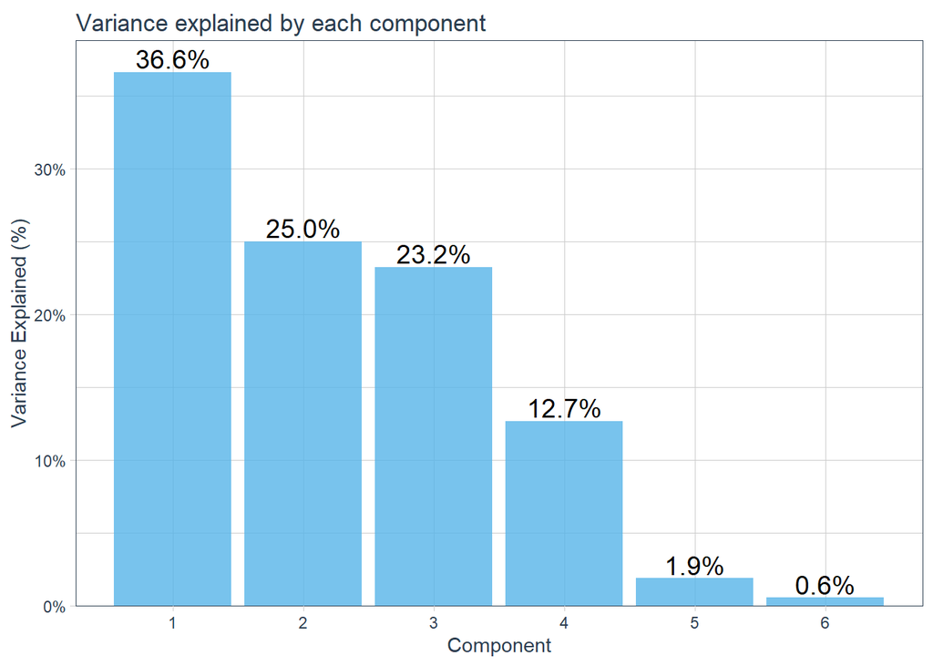

```r
library(tidyquant) # Tema visualisasi ggplot2
tabel.grafik <- cbind(stdev,prop.var,cum.var)
tabel.grafik <- as.data.frame(tabel.grafik)
comp <- c(1:p)
tabel.cum <- cbind(tabel.grafik,comp)
# Visualisasi dengan ggplot2
ggplot(tabel.cum,mapping = aes(x=comp,y=prop.var))+geom_col(fill = "#56B4E9", alpha = 0.8)+
ggtitle("Variance explained by each component") +
    xlab("Component") + ylab("Variance Explained (%)")+
    scale_x_continuous(breaks = 1:p) +
    scale_y_continuous(
        labels = scales::percent_format(),
        expand = expansion(mult = c(0, 0.06))) +
    geom_text(aes(label = scales::percent(prop.var)),
              vjust = -0.2, size = 5, position = position_dodge(0.7)) +
    theme_tq()
```

## **E. Conclusion**

> - Dari *importance of component* terlihat bahwa hanya komponen 1,2, dan 3 yang memiliki standar deviasi lebih dari 1 . Sehingga jika kita ingin mereduksi dimensi maka komponen 4, 5, dan 6 bisa kita abaikan. Diagram batang juga menunjukkan bahwa jika proporsi varians komponen 1, 2, dan 3 dijumlahkan, sudah menghasilkan nilai proporsi varians kumulatif lebih dari 70 % (memenuhi batas minimal 70% ) .
> - Kasus kita adalah menangani multikolinieritas dalam analisis regresi, maka pemilihan komponen utama bisa dilakukan secara *stepwise* atau bisa juga kita gunakan seluruh komponen utama ( metode *ente*r).
> - Sedangkan pada loadings kita bisa melihat *importance of each original variable within each component.* Contoh: variable yang penting (dominan) dalam pembentukan komponen 1 adalah manu dan popul. Dengan melihat *importance of each original variable within each component* kita dapat memberikan label pada setiap komponen utama.

## **F. Reference**

```
## #############################################################
## ##     Modul Praktikum APG Oleh Budi Yuniarto SST, M.Si    ##
## #############################################################
```